# trumpeter-swan-migration

## Trumpeter Swan (*Cygnus buccinator*) Migration Analysis using Python

Trumpeter Swans (*Cygnus buccinator*) are sensitive wetland and riparian species. Trumpeter Swans are native to North America and one of only three swan species in North America, Tundra Swans being the other native swan and Mute Swans, which native to Eurasia [(Trumpeter Swan - American Bird Conservancy)](https://abcbirds.org/bird/trumpeter-swan/#:~:text=The%20Three%20Swans,forms%20life%2Dlong%20pair%20bonds). Trumpeter Swans were once nearly extinct but have since recovered due to extensive conservation efforts. Trumpeter swans are very sensitive to pollution and human impacts on water quality. Their presence and migration are often a reflection of the health of freshwater ecosystems. They require clean and calm waters for their survival. [This makes them an indicator species](https://nhaudubon.org/a-trumpeter-swan-in-new-hampshire-a-historical-perspective), e.g. a species that is a good indicator of overall ecosystem health due to their response to ecosystem changes like pollution, habitat loss, or climate change. Trumpeter Swans occurrence data points are well-documented due to the conservation efforts to bring them back from near-extinction. This data analysis and report looks at the Trumpeter Swans migration patterns using python to join spatial data from Global Biodiversity Information Facility (GBIF) and terrestrial ecoregion data (Dinerstein et al., 2017) from World Wildlife Fund (WWF) to create a species migration map.

##### Species Description

Trumpeter Swans are the largest native birds in North America and one of the heaviest flying birds. These swans have a black beak which distinguishes it from the Mute Swan and is significantly larger than the Tundra Swan, which shares the black beak. Trumpeter swans are known for their very distinctive call, hence its namesake Trumpeter.

Trumpeter Swans require shallow lakes, marshes, wetlands, lakes, ponds and rivers with clean water and aquatic vegetation. They are mostly found in forested habitat now, but at one time were common even on the northern plains [(Trumpeter Swan | Audubon Field Guide)](https://www.audubon.org/field-guide/bird/trumpeter-swan#:~:text=Climate%20Map,range%20maintained%2083%25%20range%20lost). The Trumpeter Swan’s breeding success depends on stable water levels in northern wetlands and its migration is dependent on the availability of unfrozen wetlands. This indicates that trumpeter swans are impacted by the changing hydrology associated with climate change [(Schmidt et al., 2011)](https://www.researchgate.net/publication/232693720_Season_length_influences_breeding_range_dynamics_of_trumpeter_swans_Cygnus_buccinator). When Trumpeter Swan populations decline or change their migration routes, it is a good indicator of possible wetland degradation, water diversion, or hydrologic flow changes. This makes them a common species to determine the effectiveness of freshwater resources management and restoration efforts.

##### Methods and Data

The migration data for trumpeter swans was compiled from observations and tracking records from GBIF from the year 2022, the most recent year with a complete dataset. GBIF is an international open-access organization that collects species occurrence records and observation data. GBIF combines data from research institutions, government surveys, and as well as citizen science contributions, such as sightings reported by birdwatchers and local naturalists. Citizen science can be a powerful tool for public education and involvement, as well as increasing the availability of data points and occurrences beyond what could be collected consistently by researchers alone. While this may lead to the occasional misindentification, GBIF has functions to lessen this possibility. We have also included a normalization across space and time to help reduce this incidence.

The WWF ecoregsions dataset contains distinct ecological regions based on climate, vegetation, and species. These ecoregions are helpful internationally for conservation. Each polygon represents an area that contains similar ecosystems, making it useful for linking to species occurrence data for environmental science.

The data was joined using an inner spatial join and contains predicate using the geopandas library to determine how many observations fall within a given ecoregion. It was then plotted using hvplot.pandas library for an interactive experience of the migration data.

Data Citations:

- Species Occurence: GBIF.org (26 October 2025) GBIF Occurrence Download https://doi.org/10.15468/dl.6kxqja
- Ecoregion boundaries: Dinerstein, E., Olson, D. M., Joshi, A., Vynne, C., Burgess, N. D., & Wikramanayake, E. D. (2017). RESOLVE Ecoregions 2017. RESOLVE. Dataset accessed on October 11, 2025. https://www.resolve.ngo/projects/ecoregions-world

##### Normalization

Normalization was applied to the trumpeter swan occurrence data to account for uneven observation effort across seasons or regions. To address the differences across space and time, the values shown represent the normalized mean per ecoregion per month, which normalizes the occurrence data for spatial and temporal variations.

The mean occurrence density was calculated within each ecoregion to adjust for spatial variation in observation frequency. Then the mean occurrence was then calculated by month to correct for seasonal or temporal sampling bias. Each observation’s occurrence density was subsequently divided by the mean of its corresponding ecoregion and month, producing a normalized occurrence value that controls for both spatial and temporal variability.

This normalization method used in this data analysis allows the migration map to more accurately reflect trumpeter swan presence, abundance, and migration patterns. This reduces potential bias due to uneven sampling intensity. This allows meaningful interpretation of the occurrence data for this migration map, as well as potential for future analysis to look at changes in swan migration over time or to spatial overlay with wetland/hydrologic datasets to better understand the relationship between the two.

#### Data cleaning and wrangling (GBIF Data)

```python
# Import package for working with geospatial vector data
import geopandas as gpd

# Import package for working with tabular data
import pandas as pd

# Get month names
import calendar

# Import libraries for dynamic mapping
import cartopy.crs as ccrs
import hvplot.pandas
import panel as pn
pn.extension()

# Remove unneccesary bokeh warning from plot
from bokeh.core.validation import silence
from bokeh.core.validation.warnings import FIXED_SIZING_MODE

silence(FIXED_SIZING_MODE)
```

```
{Warning(code=1005, name='FIXED_SIZING_MODE', description="'fixed' sizing mode requires width and height to be set")}
```

```python
# Restore variables from downloading swan GBIF data and ecoregions
%store -r swan_gbif_df eco_gdf
```

```python
# Display first few rows of the GBIF dataframe to check data
swan_gbif_df.head()
```

| gbifID | decimalLatitude | decimalLongitude | month |
| --- | --- | --- | --- |
| 4646825409 | 43.628270 | -79.329170 | 1 |
| 4323802234 | 40.913990 | -81.594430 | 5 |
| 4254074916 | 43.265800 | -79.781044 | 1 |
| 4262046537 | 41.394104 | -80.913980 | 4 |
| 4285827586 | 42.273277 | -83.693400 | 1 |

```python
# Convert GBIF dataframe into GeoDataFrame
swan_gbif_gdf = (
    gpd.GeoDataFrame(
        swan_gbif_df,
        geometry=gpd.points_from_xy(
            swan_gbif_df.decimalLongitude,
            swan_gbif_df.decimalLatitude),
        crs="EPSG:4326")
    # Select the desired columns
    [['month', 'geometry']]
)

# Display GBIF GeoDataFrame
swan_gbif_gdf
```

| gbifID | month | geometry |
| --- | --- | --- |
| 4646825409 | 1 | POINT (-79.32917 43.62827) |
| 4323802234 | 5 | POINT (-81.59443 40.91399) |
| 4254074916 | 1 | POINT (-79.78104 43.2658) |
| 4262046537 | 4 | POINT (-80.91398 41.3941) |
| 4285827586 | 1 | POINT (-83.6934 42.27328) |
| ... | ... | ... |
| 3823266844 | 3 | POINT (5.85 53.2) |
| 3996487242 | 9 | POINT (-110.48186 44.67639) |
| 3822871585 | 1 | POINT (5.85 53.2) |
| 3826456857 | 3 | POINT (5.85 53.2) |
| 3753046584 | 3 | POINT (-86.7138 45.6612) |

132998 rows × 2 columns

#### Data Wrangling (WWF Ecoregions Data)

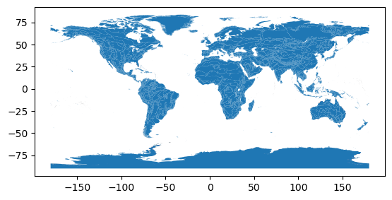

```python
# Plot the ecoregions quickly to check download
eco_gdf.plot()
```

```python
# Look at the data from ecoregions
eco_gdf.head()
```

| ecoregion_id | name | area | geometry |
| --- | --- | --- | --- |
| 1.0 | Adelie Land tundra | 0.038948 | MULTIPOLYGON (((158.7141 -69.60657, 158.71264 ... |
| 2.0 | Admiralty Islands lowland rain forests | 0.170599 | MULTIPOLYGON (((147.28819 -2.57589, 147.2715 -... |
| 3.0 | Aegean and Western Turkey sclerophyllous and m... | 13.844952 | MULTIPOLYGON (((26.88659 35.32161, 26.88297 35... |
| 4.0 | Afghan Mountains semi-desert | 1.355536 | MULTIPOLYGON (((65.48655 34.71401, 65.52872 34... |
| 5.0 | Ahklun and Kilbuck Upland Tundra | 8.196573 | MULTIPOLYGON (((-160.26404 58.64097, -160.2673... |

```python
# Spatially join both geodataframes together
swan_gbif_ecoregion_gdf = (
    eco_gdf
    # Match the CRS of the GBIF data and the ecoregions
    .to_crs(swan_gbif_gdf.crs)
    # Find ecoregion for each observation
    .sjoin(
        swan_gbif_gdf,
        # Use inner join to include only observations inside a defined ecoregion
        how='inner',
        # Use contains to identify which ecoregion polygon each observation is within
        predicate='contains')
)

# Call joined geodataframes
swan_gbif_ecoregion_gdf
```

| ecoregion_id | name | area | geometry | gbifID | month |
| --- | --- | --- | --- | --- | --- |
| 10.0 | Alaska-St. Elias Range tundra | 28.388010 | MULTIPOLYGON (((-153.53084 59.3926, -153.52838... | 4202434028 | 6 |
| 10.0 | Alaska-St. Elias Range tundra | 28.388010 | MULTIPOLYGON (((-153.53084 59.3926, -153.52838... | 4238420359 | 6 |
| 10.0 | Alaska-St. Elias Range tundra | 28.388010 | MULTIPOLYGON (((-153.53084 59.3926, -153.52838... | 4267855185 | 7 |
| 10.0 | Alaska-St. Elias Range tundra | 28.388010 | MULTIPOLYGON (((-153.53084 59.3926, -153.52838... | 5624991828 | 8 |
| 10.0 | Alaska-St. Elias Range tundra | 28.388010 | MULTIPOLYGON (((-153.53084 59.3926, -153.52838... | 4313205482 | 7 |
| ... | ... | ... | ... | ... | ... |
| 839.0 | Northern Rockies conifer forests | 35.905513 | POLYGON ((-119.99977 54.53117, -119.8914 54.45... | 4274774279 | 5 |
| 839.0 | Northern Rockies conifer forests | 35.905513 | POLYGON ((-119.99977 54.53117, -119.8914 54.45... | 4256768815 | 6 |
| 839.0 | Northern Rockies conifer forests | 35.905513 | POLYGON ((-119.99977 54.53117, -119.8914 54.45... | 4351526396 | 2 |
| 839.0 | Northern Rockies conifer forests | 35.905513 | POLYGON ((-119.99977 54.53117, -119.8914 54.45... | 4370185641 | 11 |
| 839.0 | Northern Rockies conifer forests | 35.905513 | POLYGON ((-119.99977 54.53117, -119.8914 54.45... | 4251779741 | 6 |

124174 rows × 5 columns

### Normalization of Data for Temporal and Spatial Variability

```python
# Group observations by ecoregion
swan_occurrence_df = (
    swan_gbif_ecoregion_gdf
    # Reset index
    .reset_index()
    # For each ecoregion, for each month...
    .groupby(['ecoregion_id', 'month'])
    # Count the number of occurrences
    .agg(occurrences=('gbifID', 'count'),
    area=('area', 'mean')
)
)

# Normalize by area
swan_occurrence_df['density'] = (
    swan_occurrence_df.occurrences
    / swan_occurrence_df.area
)
# Get rid of rare observations (possible misidentification?)
swan_occurrence_df = swan_occurrence_df[swan_occurrence_df.occurrences>1]

# Call observations by ecoregion
swan_occurrence_df
```

| ecoregion_id | month | occurrences | area | density |
| --- | --- | --- | --- | --- |
| 10.0 | 4 | 4 | 28.388010 | 0.140905 |
|  | 5 | 38 | 28.388010 | 1.338593 |
|  | 6 | 241 | 28.388010 | 8.489500 |
|  | 7 | 61 | 28.388010 | 2.148794 |
|  | 8 | 28 | 28.388010 | 0.986332 |
| ... | ... | ... | ... | ... |
| 839.0 | 8 | 131 | 35.905513 | 3.648465 |
|  | 9 | 151 | 35.905513 | 4.205482 |
|  | 10 | 149 | 35.905513 | 4.149781 |
|  | 11 | 201 | 35.905513 | 5.598026 |
|  | 12 | 62 | 35.905513 | 1.726754 |

627 rows × 3 columns

```python
# Take the mean by ecoregion for temporal normalization for ecoregion seasonal bias
swan_mean_occurrences_by_ecoregion = (
    swan_occurrence_df
    .groupby('ecoregion_id')
    .mean()
)
# Call the mean by ecoregion calculated
swan_mean_occurrences_by_ecoregion
```

| ecoregion_id | occurrences | area | density |
| --- | --- | --- | --- |
| 10.0 | 63.833333 | 28.388010 | 2.248602 |
| 11.0 | 10.272727 | 7.247315 | 1.417453 |
| 13.0 | 16.000000 | 17.133639 | 0.933835 |
| 17.0 | 17.583333 | 7.958751 | 2.209308 |
| 33.0 | 29.083333 | 16.637804 | 1.748027 |
| ... | ... | ... | ... |
| 821.0 | 24.571429 | 26.034401 | 0.943806 |
| 826.0 | 2.000000 | 1.382287 | 1.446878 |
| 827.0 | 61.500000 | 9.664680 | 6.363377 |
| 838.0 | 13.900000 | 4.286144 | 3.243008 |
| 839.0 | 227.916667 | 35.905513 | 6.347679 |

82 rows × 3 columns

```python
# Take the mean by month to normalize seasonal sampling bias across months
swan_mean_occurrences_by_month = (
    swan_occurrence_df
    .groupby('month')
    .mean()
)

# Call the mean by month calculated
swan_mean_occurrences_by_month
```

| month | occurrences | area | density |
| --- | --- | --- | --- |
| 1 | 238.618182 | 18.156501 | 29.935219 |
| 2 | 181.111111 | 18.588751 | 21.691089 |
| 3 | 262.962264 | 20.253262 | 20.907159 |
| 4 | 269.842105 | 24.325771 | 16.008215 |
| 5 | 390.074074 | 25.772912 | 19.722871 |
| 6 | 149.769231 | 26.423842 | 9.034934 |
| 7 | 98.313725 | 28.529728 | 5.717252 |
| 8 | 134.418605 | 28.067656 | 7.969694 |
| 9 | 134.297872 | 25.777173 | 7.749847 |
| 10 | 147.040816 | 25.090251 | 9.281995 |
| 11 | 169.689655 | 21.374487 | 18.897747 |
| 12 | 164.796296 | 18.747952 | 20.806854 |

```python
# Normalize by space and time for sampling effort
swan_occurrence_df['norm_occurrences'] = (
    swan_occurrence_df[['density']]
    / swan_mean_occurrences_by_ecoregion[['density']]
    / swan_mean_occurrences_by_month[['density']]
)

# Call occurance data after normalization
swan_occurrence_df
```

| ecoregion_id | month | occurrences | area | density | norm_occurrences |
| --- | --- | --- | --- | --- | --- |
| 10.0 | 4 | 4 | 28.388010 | 0.140905 | 0.003914 |
|  | 5 | 38 | 28.388010 | 1.338593 | 0.030183 |
|  | 6 | 241 | 28.388010 | 8.489500 | 0.417873 |
|  | 7 | 61 | 28.388010 | 2.148794 | 0.167146 |
|  | 8 | 28 | 28.388010 | 0.986332 | 0.055039 |
| ... | ... | ... | ... | ... | ... |
| 839.0 | 8 | 131 | 35.905513 | 3.648465 | 0.072120 |
|  | 9 | 151 | 35.905513 | 4.205482 | 0.085489 |
|  | 10 | 149 | 35.905513 | 4.149781 | 0.070432 |
|  | 11 | 201 | 35.905513 | 5.598026 | 0.046667 |
|  | 12 | 62 | 35.905513 | 1.726754 | 0.013074 |

627 rows × 4 columns

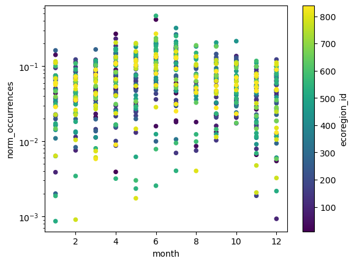

```python
# Quickly view dataframe to see how normalization looks
# Check for patterns or anomalies, label in future
swan_occurrence_df.reset_index().plot.scatter(
    x='month', y='norm_occurrences', c='ecoregion_id',
    logy=True
)
```

### Plotting the Joined Migration Data for Trumpeter Swans

```python
# Simplify the geometry to speed up processing
eco_gdf.geometry = eco_gdf.simplify(.1, preserve_topology=False)

# Change the CRS to Mercator for mapping
eco_gdf = eco_gdf.to_crs(ccrs.Mercator())

# Check that the plot runs in a reasonable amount of time
eco_gdf.hvplot(geo=True, crs=ccrs.Mercator())
```

```python
# View first few rows of data from occurance dataframe
swan_occurrence_df.head()
```

| ecoregion_id | month | occurrences | area | density | norm_occurrences |
| --- | --- | --- | --- | --- | --- |
| 10.0 | 4 | 4 | 28.38801 | 0.140905 | 0.003914 |
|  | 5 | 38 | 28.38801 | 1.338593 | 0.030183 |
|  | 6 | 241 | 28.38801 | 8.489500 | 0.417873 |
|  | 7 | 61 | 28.38801 | 2.148794 | 0.167146 |
|  | 8 | 28 | 28.38801 | 0.986332 | 0.055039 |

```python
# Join the occurrences with the plotting GeoDataFrame
swan_occurrence_df = eco_gdf.join(swan_occurrence_df[['norm_occurrences']])

# Get the plot bounds so they don't change with the slider
xmin, ymin, xmax, ymax = swan_gbif_gdf.to_crs(ccrs.Mercator()).total_bounds

# Create widget to rename months from number to names
month_widget = pn.widgets.DiscreteSlider(
    options={
        calendar.month_name[month_num]: month_num
        for month_num in range(1,13)
    }
)

# Plot occurrence by ecoregion and month
swan_migration_plot = (
    swan_occurrence_df
    .hvplot(
        c='norm_occurrences',
        groupby='month',
        # Use background tiles
        geo=True, crs=ccrs.Mercator(), tiles='CartoLight',
        title="Monthly Migration Patterns of Trumpeter Swans (Normalized Occurrence Mean)",
        xlim=(xmin, xmax), ylim=(ymin, ymax),
        frame_width=600,
        widgets={'month': month_widget},
        widget_location='bottom',
        color='norm_occurrences', # Choose map color
        cmap='Viridis', # Choose a colormap **code help ChatGPT**
    )
)

# Save the plot as html
swan_migration_plot.save('trumpeter_swan_migration_plot.html', embed=True)

# Show plot
swan_migration_plot
```

```
BokehModel(combine_events=True, render_bundle={'docs_json': {'eab48e7f-f3be-40c2-b2d6-b8d9e757268c': {'version…
```

[figure not shown]

## Following the Flight: Where Can You Find the Trumpeter Swan (*Cygnus buccinator*) Throughout the Year?

Trumpeter Swans are a symbol of resilience, grace, and beauty. They also tell a story of successful conservation efforts to protect wetlands and threatened species. Following their migration on the map above, Trumpeter Swans spend the winter in inland areas such as the Midwest and along the U.S. coasts where waters remain ice-free. They then travel to remote regions such as Alaska, Canada, and the northwestern U.S. to breed in the spring and summer [(Cornell Lab of Ornithology, n.d.).](https://www.allaboutbirds.org/guide/Trumpeter_Swan/overview)

Only about 10 % of trumpeter swans are long-distance migrants. Many others migrate a moderate distance, some a short distance, and a few populations are non-migratory, staying relatively local to their breeding grounds [(BirdFact, 2023).](https://birdfact.com/articles/trumpeter-swan-migration) There are three subpopulations of trumpeter swans: the Pacific, the Rocky Mountain, and the Interior. They fly in small family groups of 10 - 25 birds. Trumpeter Swans are sensitive to failed hatches due to human disturbance, which is one reason they need calm and undisturbed water habitat for successful breeding [(U.S. National Park Service, 2025).](https://www.nps.gov/yell/learn/nature/trumpeter-swan.htm)

Some of the populations that are visible in certain regions year-round are from swan populations that were reintroduced due to conservation efforts in areas like Oregon and Yellowstone National Park. Some of these southern populations no longer migrate at all, as ice-free waters are available year-round close to their breeding grounds.

Recovering from near-extinction due to hunting, habitat loss, pollution, and human disturbance is not an easy feat. Trumpeter Swans have made a serious comeback, but the fight is far from over for birds that are impacted by humans and climate change. Trumpeter swans are an iconic and easily identifiable bird. They are an important indicator species for freshwater ecosystem health and water resources management more broadly. Using this species migration interactive map, you can follow them as they travel to find habitat with clean and calm waters.

This data analysis used Python to work with occurrence data from GBIF, spatially joined to WWF ecoregion polygons, to create the species migration map. The normalized mean occurrence was used to reduce spatial and temporal sampling variability. While this data analysis did not yet include wetland characteristics, water quality, or hydrologic data, it could provide a valuable foundation and direction for future environmental data science studies. By combining Trumpeter Swan migration patterns with wetland, hydrologic, or even climate data, researchers could investigate associations between swan occurrences and freshwater ecosystem health, detect environmental changes over time, and inform water resources management for data-driven decisions.

### References

- American Bird Conservancy. (n.d.). Trumpeter Swan. American Bird Conservancy. Retrieved October 26, 2025, from https://abcbirds.org/bird/trumpeter-swan/
- BirdFact. (2023, January 22). Trumpeter Swan migration: A complete guide. https://birdfact.com/articles/trumpeter-swan-migration
- Cornell Lab of Ornithology. (n.d.). Trumpeter Swan. All About Birds. https://www.allaboutbirds.org/guide/Trumpeter_Swan/overview
- National Audubon Society. (n.d.). Trumpeter Swan. Audubon. Retrieved October 26, 2025, from https://www.audubon.org/field-guide/bird/trumpeter-swan
- Schmidt, J. H., Lindberg, M. S., Johnson, D. S., Conant, B., & King, J. G. (2011). Season length influences breeding range dynamics of trumpeter swans Cygnus buccinator. Wildlife Biology, 17(4), 364–372. https://doi.org/10.2981/11-003
- Stephens, D. (2019, November 4). A Trumpeter Swan in New Hampshire! A Historical Perspective. New Hampshire Audubon. https://nhaudubon.org/a-trumpeter-swan-in-new-hampshire-a-historical-perspective/
- U.S. National Park Service. (2025, April 18). Trumpeter Swan. Yellowstone National Park. https://www.nps.gov/yell/learn/nature/trumpeter-swan.htm